# Análisis Multivariado: ACP, MCA y LDA

Ricardo Macías Bohórquez

21 de October de 2024

# Análisis Multivariado: ACP, MCA y LDA

En este documento, exploraremos tres métodos populares de análisis multivariado: **Análisis de Componentes Principales (ACP)**, **Análisis de Correspondencias Múltiples (MCA)** y **Análisis Discriminante Lineal (LDA)**. Estas técnicas nos permiten estudiar relaciones complejas entre múltiples variables, reducir la dimensionalidad y clasificar observaciones.

## 1. Análisis de Componentes Principales (ACP)

### 1.1 Explicación del ACP

El **Análisis de Componentes Principales (ACP)** es una técnica que se utiliza para reducir la dimensionalidad de los datos mientras se conserva la mayor cantidad de información posible. Convierte un conjunto de variables correlacionadas en un conjunto más pequeño de variables no correlacionadas llamadas **componentes principales**.

#### **Objetivo**:

- Reducir la dimensionalidad del conjunto de datos.
- Explicar la variabilidad en los datos utilizando un número reducido de componentes.

### 1.2 Ejemplo: ACP sobre `mtcars`

#### 1. Cargar y visualizar los datos

```r
# Cargar el conjunto de datos mtcars
data(mtcars)

# Seleccionar las variables numéricas para realizar el ACP
datos_acp <- mtcars[, c("mpg", "hp", "wt", "qsec", "drat")]

# Mostrar las primeras filas
head(datos_acp)
```

```
##                    mpg  hp    wt  qsec drat
## Mazda RX4         21.0 110 2.620 16.46 3.90
## Mazda RX4 Wag     21.0 110 2.875 17.02 3.90
## Datsun 710        22.8  93 2.320 18.61 3.85
## Hornet 4 Drive    21.4 110 3.215 19.44 3.08
## Hornet Sportabout 18.7 175 3.440 17.02 3.15
## Valiant           18.1 105 3.460 20.22 2.76
```

#### 2. Realizar el ACP

```r
# Realizar el Análisis de Componentes Principales (ACP)
acp_mtcars <- prcomp(datos_acp, scale. = TRUE)

# Mostrar el resumen del ACP
summary(acp_mtcars)
```

```
## Importance of components:
##                           PC1    PC2     PC3     PC4     PC5
## Standard deviation     1.8176 1.0690 0.57508 0.36325 0.30135
## Proportion of Variance 0.6607 0.2286 0.06614 0.02639 0.01816
## Cumulative Proportion  0.6607 0.8893 0.95545 0.98184 1.00000
```

#### 3. Visualizar el Biplot

El **biplot** es una representación gráfica del ACP que muestra cómo las variables originales se proyectan en los componentes principales.

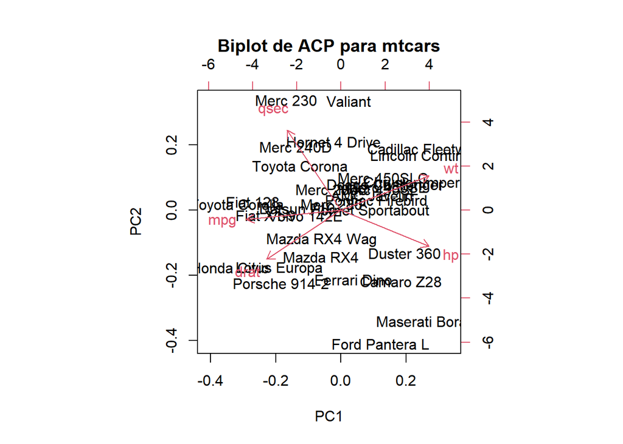

```r
# Gráfico Biplot del ACP
biplot(acp_mtcars, main = "Biplot de ACP para mtcars")
```

### 1.3 Interpretación

En el biplot, podemos ver cómo las variables originales influyen en los componentes principales. Los autos que están más cercanos entre sí en el gráfico son más similares en cuanto a sus valores en las variables originales. Los ejes del gráfico representan los dos primeros componentes principales, que capturan la mayor parte de la variabilidad en los datos.

## 2. Análisis de Correspondencias Múltiples (MCA)

### 2.1 Explicación del MCA

El **Análisis de Correspondencias Múltiples (MCA)** es una extensión del análisis de correspondencias para manejar más de dos variables cualitativas. Se utiliza para detectar y representar gráficamente las asociaciones entre múltiples variables categóricas.

#### **Objetivo**:

- Estudiar las relaciones entre varias variables categóricas.
- Identificar asociaciones y patrones en los datos cualitativos.

### 2.2 Ejemplo: MCA sobre `HairEyeColor`

#### 1. Crear un conjunto de datos simplificado

Usaremos la base de datos `HairEyeColor`, simplificando a solo dos variables categóricas: **Color de Pelo** y **Color de Ojos**.

```r
# Cargar los datos de HairEyeColor
data(HairEyeColor)

# Convertir la tabla a un data.frame
df_hair_eye <- as.data.frame(HairEyeColor)

# Seleccionar las variables categóricas
df_mca <- df_hair_eye[, c("Hair", "Eye")]

# Mostrar las primeras filas
head(df_mca)
```

```
##    Hair   Eye
## 1 Black Brown
## 2 Brown Brown
## 3   Red Brown
## 4 Blond Brown
## 5 Black  Blue
## 6 Brown  Blue
```

#### 2. Realizar el MCA

```r
# Instalar y cargar el paquete FactoMineR si es necesario
# install.packages("FactoMineR")
library(FactoMineR)

# Realizar el MCA
mca_hair_eye <- MCA(df_mca, graph = FALSE)

# Mostrar el resumen del MCA
summary(mca_hair_eye)
```

```
##
## Call:
## MCA(X = df_mca, graph = FALSE)
##
##
## Eigenvalues
##                        Dim.1   Dim.2   Dim.3   Dim.4   Dim.5   Dim.6
## Variance               0.500   0.500   0.500   0.500   0.500   0.500
## % of var.             16.667  16.667  16.667  16.667  16.667  16.667
## Cumulative % of var.  16.667  33.333  50.000  66.667  83.333 100.000
##
## Individuals (the 10 first)
##               Dim.1    ctr   cos2    Dim.2    ctr   cos2    Dim.3    ctr   cos2
## 1          | -1.225  9.375  0.500 | -0.008  0.000  0.000 |  0.032  0.006  0.000
## 2          |  0.408  1.042  0.056 | -0.212  0.282  0.015 |  0.001  0.000  0.000
## 3          |  0.408  1.042  0.056 | -0.889  4.940  0.263 |  0.006  0.000  0.000
## 4          |  0.408  1.042  0.056 |  1.077  7.248  0.387 |  0.088  0.048  0.003
## 5          | -1.225  9.375  0.500 | -0.044  0.012  0.001 |  1.127  7.937  0.423
## 6          |  0.408  1.042  0.056 | -0.248  0.385  0.021 |  1.096  7.512  0.401
## 7          |  0.408  1.042  0.056 | -0.925  5.345  0.285 |  1.102  7.583  0.404
## 8          |  0.408  1.042  0.056 |  1.041  6.775  0.361 |  1.183  8.746  0.466
## 9          | -1.225  9.375  0.500 | -0.003  0.000  0.000 | -0.416  1.082  0.058
## 10         |  0.408  1.042  0.056 | -0.207  0.268  0.014 | -0.447  1.247  0.067
##
## 1          |
## 2          |
## 3          |
## 4          |
## 5          |
## 6          |
## 7          |
## 8          |
## 9          |
## 10         |
##
## Categories
##               Dim.1    ctr   cos2 v.test    Dim.2    ctr   cos2 v.test    Dim.3
## Hair_Black | -1.732 75.000  1.000 -5.568 |  0.000  0.000  0.000  0.000 |  0.000
## Hair_Brown |  0.577  8.333  0.111  1.856 | -0.289  2.086  0.028 -0.929 | -0.043
## Hair_Red   |  0.577  8.333  0.111  1.856 | -1.246 38.792  0.517 -4.004 | -0.036
## Hair_Blond |  0.577  8.333  0.111  1.856 |  1.535 58.870  0.785  4.933 |  0.079
## Eye_Brown  |  0.000  0.000  0.000  0.000 | -0.012  0.003  0.000 -0.037 |  0.045
## Eye_Blue   |  0.000  0.000  0.000  0.000 | -0.062  0.096  0.001 -0.200 |  1.594
## Eye_Hazel  |  0.000  0.000  0.000  0.000 | -0.004  0.000  0.000 -0.013 | -0.588
## Eye_Green  |  0.000  0.000  0.000  0.000 |  0.078  0.152  0.002  0.250 | -1.050
##               ctr   cos2 v.test
## Hair_Black  0.000  0.000  0.000 |
## Hair_Brown  0.047  0.001 -0.139 |
## Hair_Red    0.032  0.000 -0.116 |
## Hair_Blond  0.157  0.002  0.255 |
## Eye_Brown   0.050  0.001  0.144 |
## Eye_Blue   63.497  0.847  5.123 |
## Eye_Hazel   8.656  0.115 -1.891 |
## Eye_Green  27.561  0.367 -3.375 |
##
## Categorical variables (eta2)
##              Dim.1 Dim.2 Dim.3
## Hair       | 1.000 0.997 0.002 |
## Eye        | 0.000 0.003 0.998 |
```

#### 3. Visualizar el Gráfico del MCA

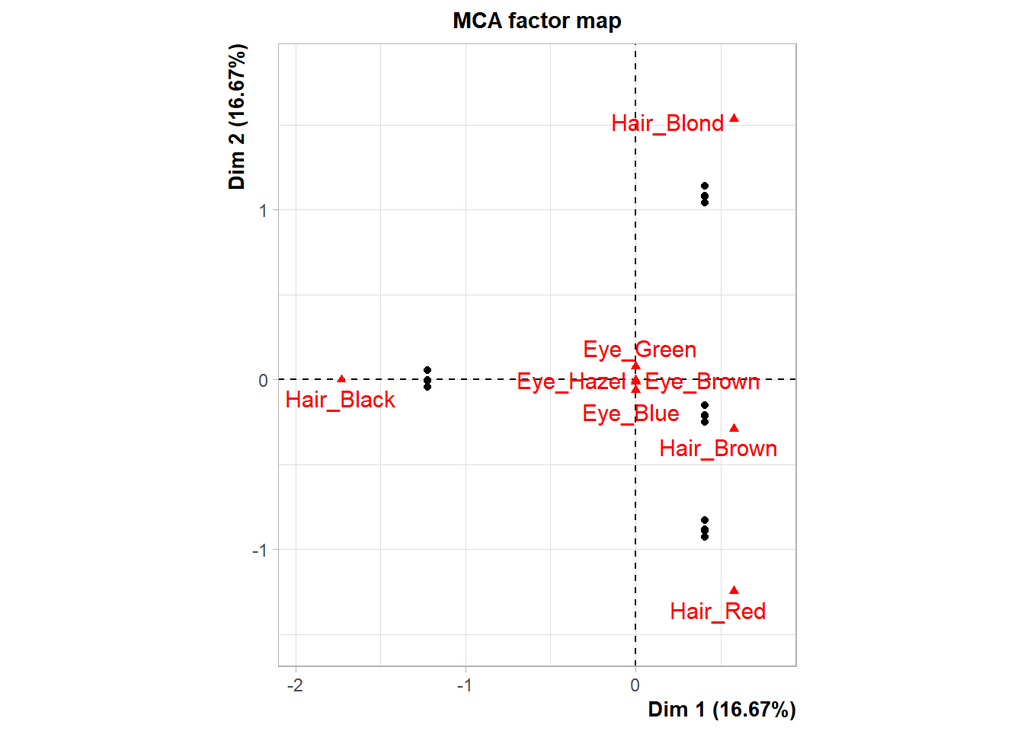

```r
# Gráfico del Análisis de Correspondencias Múltiples
plot(mca_hair_eye, invisible = "quali.sup", main = "MCA: Hair vs Eye Color")
```

```r
# Instalar y cargar factoextra si es necesario
# install.packages("factoextra")
library(FactoMineR)
library(factoextra)
```

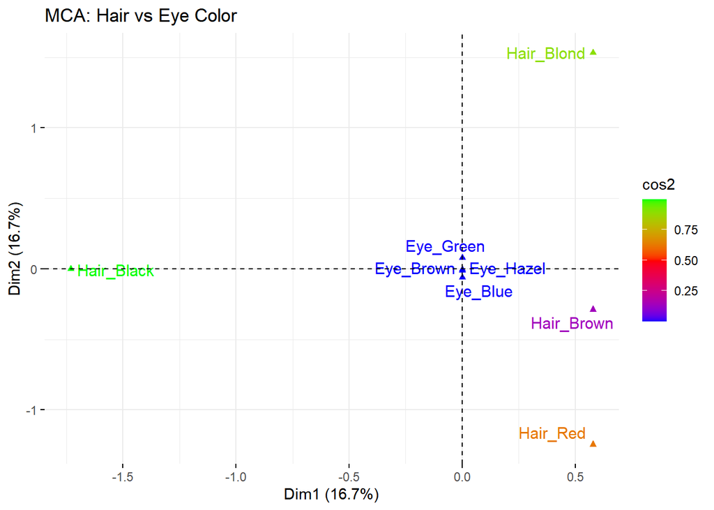

```r
# Realizar el Análisis de Correspondencias Múltiples (MCA)
mca_hair_eye <- MCA(df_mca, graph = FALSE)

# Gráfico del MCA utilizando factoextra con diferentes colores para las variables
fviz_mca_var(mca_hair_eye,
             col.var = "cos2",       # Color por calidad de la representación
             gradient.cols = c("blue", "red", "green"), # Paleta de colores
             repel = TRUE,            # Evitar la superposición de etiquetas
             title = "MCA: Hair vs Eye Color")
```

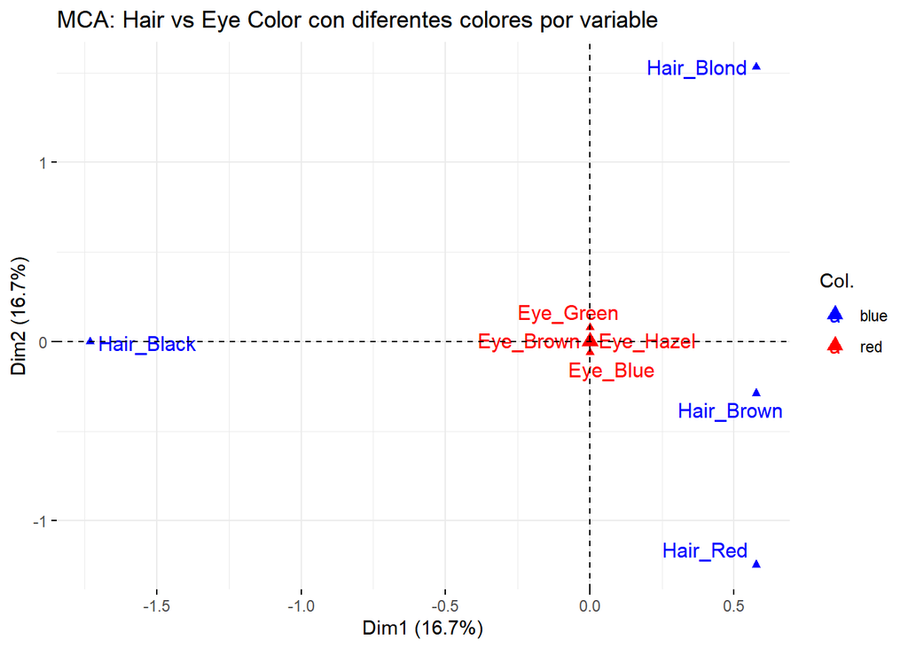

```r
# Cargar el dataset HairEyeColor y convertirlo en un data frame
hair_eye_data <- as.data.frame(HairEyeColor)

# Solo nos interesa el color del cabello (Hair) y los ojos (Eye)
hair_eye_data <- hair_eye_data[, c("Hair", "Eye")]

# Realizar el Análisis de Correspondencias Múltiples (MCA)
mca_hair_eye <- MCA(hair_eye_data, graph = FALSE)

# Asignar colores diferentes para cada grupo de variables
fviz_mca_var(mca_hair_eye,
             col.var = c(rep("blue", 4), rep("red", 4)), # Colorear Hair en azul y Eye en rojo
             palette = c("blue", "red"),  # Define una paleta de colores
             repel = TRUE,                 # Evitar la superposición de etiquetas
             title = "MCA: Hair vs Eye Color con diferentes colores por variable")
```

### 2.3 Interpretación

El gráfico de MCA muestra las asociaciones entre las categorías de las variables cualitativas. Las categorías que se encuentran más cerca en el gráfico están más asociadas en los datos.

## 3. Análisis Discriminante Lineal (LDA)

### 3.1 Explicación del LDA

El **Análisis Discriminante Lineal (LDA)** se utiliza para encontrar una combinación lineal de variables que maximice la separación entre grupos. Es útil para clasificar observaciones en diferentes categorías en función de varias variables predictoras.

#### **Objetivo**:

- Clasificar observaciones en categorías conocidas.
- Maximizar la separación entre grupos.

### 3.2 Ejemplo: LDA en `iris`

#### 1. Cargar y visualizar los datos

```r
# Cargar el conjunto de datos iris
data(iris)

# Ver las primeras filas
head(iris)
```

```
##   Sepal.Length Sepal.Width Petal.Length Petal.Width Species
## 1          5.1         3.5          1.4         0.2  setosa
## 2          4.9         3.0          1.4         0.2  setosa
## 3          4.7         3.2          1.3         0.2  setosa
## 4          4.6         3.1          1.5         0.2  setosa
## 5          5.0         3.6          1.4         0.2  setosa
## 6          5.4         3.9          1.7         0.4  setosa
```

#### 2. Realizar el LDA

```r
# Instalar y cargar el paquete MASS si es necesario
# install.packages("MASS")
library(MASS)

# Realizar el Análisis Discriminante Lineal
lda_iris <- lda(Species ~ Sepal.Length + Sepal.Width + Petal.Length + Petal.Width, data = iris)

# Mostrar el modelo ajustado
print(lda_iris)
```

```
## Call:
## lda(Species ~ Sepal.Length + Sepal.Width + Petal.Length + Petal.Width,
##     data = iris)
##
## Prior probabilities of groups:
##     setosa versicolor  virginica
##  0.3333333  0.3333333  0.3333333
##
## Group means:
##            Sepal.Length Sepal.Width Petal.Length Petal.Width
## setosa            5.006       3.428        1.462       0.246
## versicolor        5.936       2.770        4.260       1.326
## virginica         6.588       2.974        5.552       2.026
##
## Coefficients of linear discriminants:
##                     LD1         LD2
## Sepal.Length  0.8293776 -0.02410215
## Sepal.Width   1.5344731 -2.16452123
## Petal.Length -2.2012117  0.93192121
## Petal.Width  -2.8104603 -2.83918785
##
## Proportion of trace:
##    LD1    LD2
## 0.9912 0.0088
```

#### 3. Visualizar los Resultados del LDA

Podemos visualizar las dos primeras funciones discriminantes para observar cómo se separan las especies en el espacio discriminante.

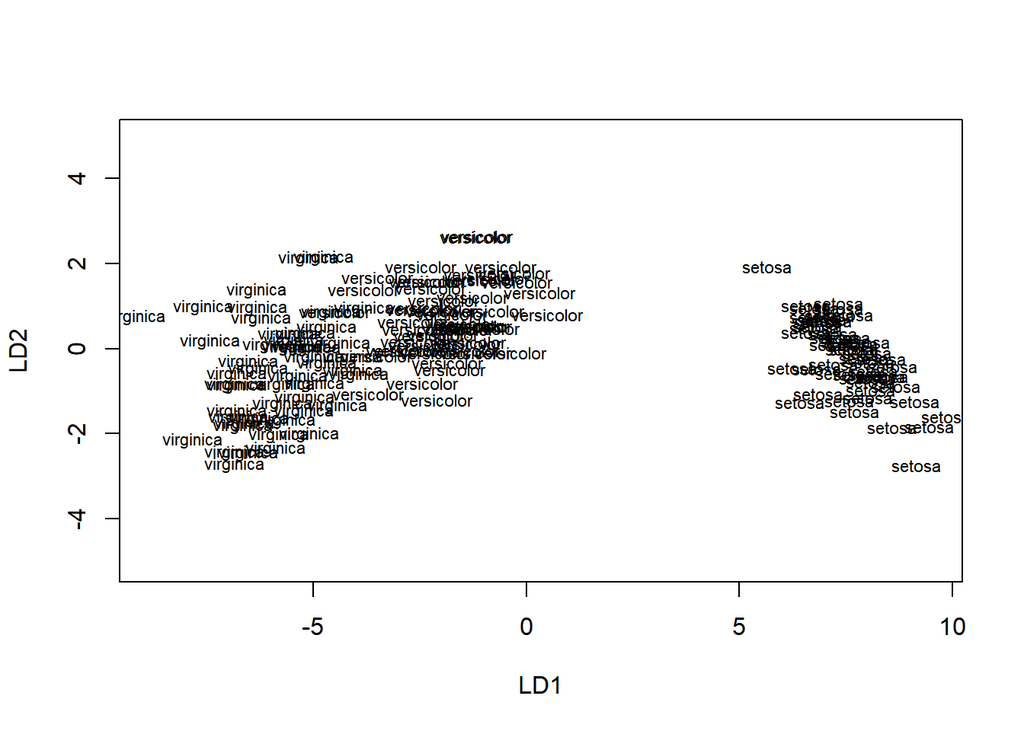

```r
# Gráfico de las dos primeras funciones discriminantes
plot(lda_iris)
```

### 3.3 Interpretación

El gráfico muestra cómo las diferentes especies de flores se separan en función de las variables predictoras. Las especies que se encuentran más alejadas en el gráfico están bien separadas en el espacio de las funciones discriminantes.

## 4. Ejercicios Prácticos

### **Ejercicio 1**: Análisis de Componentes Principales

Realiza un ACP sobre las variables numéricas de `mtcars`. Visualiza el biplot e interpreta los resultados.

```r
# Tu código aquí
```

**Mostrar solución**

```r
# Realizar el ACP sobre mtcars
acp_mtcars <- prcomp(mtcars[, c("mpg", "hp", "wt")], scale. = TRUE)

# Mostrar el resumen del ACP
summary(acp_mtcars)
```

```
## Importance of components:
##                           PC1    PC2     PC3
## Standard deviation     1.5932 0.5934 0.33123
## Proportion of Variance 0.8461 0.1174 0.03657
## Cumulative Proportion  0.8461 0.9634 1.00000
```

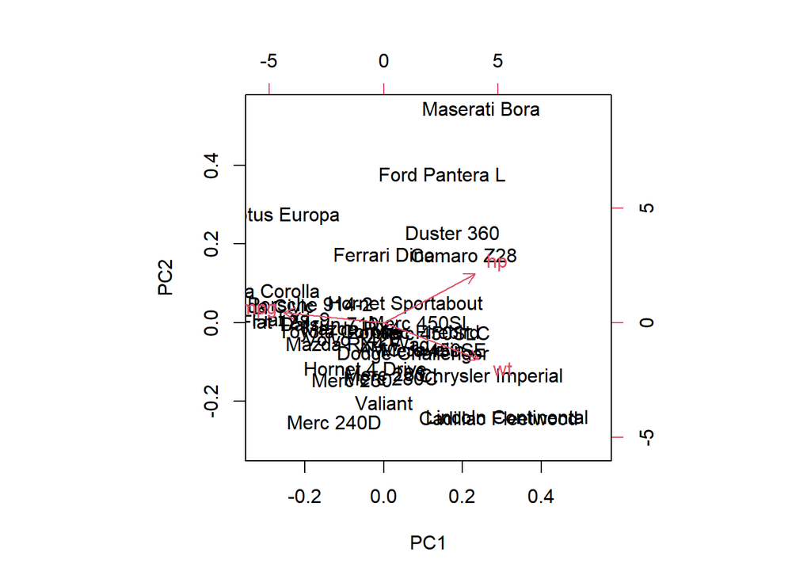

```r
# Visualizar el biplot
biplot(acp_mtcars)
```

### **Ejercicio 2**: Análisis de Correspondencias Múltiples

Usa la base de datos `HairEyeColor` para realizar un MCA sobre las variables `Hair` y `Eye`. Interpreta los resultados.

```r
# Tu código aquí
```

**Mostrar solución**

```r
#Realizar el MCA sobre Hair y Eye
mca_hair_eye <- MCA(df_mca, graph = FALSE)

# Mostrar el resumen
summary(mca_hair_eye)
```

```
##
## Call:
## MCA(X = df_mca, graph = FALSE)
##
##
## Eigenvalues
##                        Dim.1   Dim.2   Dim.3   Dim.4   Dim.5   Dim.6
## Variance               0.500   0.500   0.500   0.500   0.500   0.500
## % of var.             16.667  16.667  16.667  16.667  16.667  16.667
## Cumulative % of var.  16.667  33.333  50.000  66.667  83.333 100.000
##
## Individuals (the 10 first)
##               Dim.1    ctr   cos2    Dim.2    ctr   cos2    Dim.3    ctr   cos2
## 1          | -1.225  9.375  0.500 | -0.008  0.000  0.000 |  0.032  0.006  0.000
## 2          |  0.408  1.042  0.056 | -0.212  0.282  0.015 |  0.001  0.000  0.000
## 3          |  0.408  1.042  0.056 | -0.889  4.940  0.263 |  0.006  0.000  0.000
## 4          |  0.408  1.042  0.056 |  1.077  7.248  0.387 |  0.088  0.048  0.003
## 5          | -1.225  9.375  0.500 | -0.044  0.012  0.001 |  1.127  7.937  0.423
## 6          |  0.408  1.042  0.056 | -0.248  0.385  0.021 |  1.096  7.512  0.401
## 7          |  0.408  1.042  0.056 | -0.925  5.345  0.285 |  1.102  7.583  0.404
## 8          |  0.408  1.042  0.056 |  1.041  6.775  0.361 |  1.183  8.746  0.466
## 9          | -1.225  9.375  0.500 | -0.003  0.000  0.000 | -0.416  1.082  0.058
## 10         |  0.408  1.042  0.056 | -0.207  0.268  0.014 | -0.447  1.247  0.067
##
## 1          |
## 2          |
## 3          |
## 4          |
## 5          |
## 6          |
## 7          |
## 8          |
## 9          |
## 10         |
##
## Categories
##               Dim.1    ctr   cos2 v.test    Dim.2    ctr   cos2 v.test    Dim.3
## Hair_Black | -1.732 75.000  1.000 -5.568 |  0.000  0.000  0.000  0.000 |  0.000
## Hair_Brown |  0.577  8.333  0.111  1.856 | -0.289  2.086  0.028 -0.929 | -0.043
## Hair_Red   |  0.577  8.333  0.111  1.856 | -1.246 38.792  0.517 -4.004 | -0.036
## Hair_Blond |  0.577  8.333  0.111  1.856 |  1.535 58.870  0.785  4.933 |  0.079
## Eye_Brown  |  0.000  0.000  0.000  0.000 | -0.012  0.003  0.000 -0.037 |  0.045
## Eye_Blue   |  0.000  0.000  0.000  0.000 | -0.062  0.096  0.001 -0.200 |  1.594
## Eye_Hazel  |  0.000  0.000  0.000  0.000 | -0.004  0.000  0.000 -0.013 | -0.588
## Eye_Green  |  0.000  0.000  0.000  0.000 |  0.078  0.152  0.002  0.250 | -1.050
##               ctr   cos2 v.test
## Hair_Black  0.000  0.000  0.000 |
## Hair_Brown  0.047  0.001 -0.139 |
## Hair_Red    0.032  0.000 -0.116 |
## Hair_Blond  0.157  0.002  0.255 |
## Eye_Brown   0.050  0.001  0.144 |
## Eye_Blue   63.497  0.847  5.123 |
## Eye_Hazel   8.656  0.115 -1.891 |
## Eye_Green  27.561  0.367 -3.375 |
##
## Categorical variables (eta2)
##              Dim.1 Dim.2 Dim.3
## Hair       | 1.000 0.997 0.002 |
## Eye        | 0.000 0.003 0.998 |
```

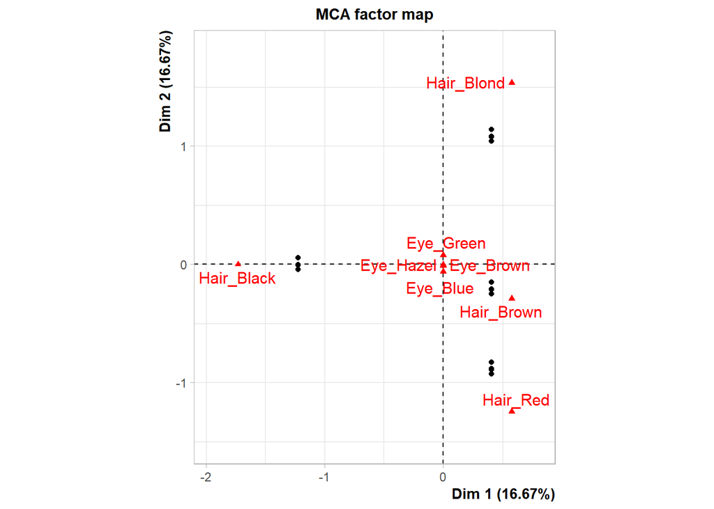

```r
# Visualizar el gráfico de MCA
plot(mca_hair_eye, invisible = "quali.sup", main = "MCA: Hair vs Eye Color")
```

### **Ejercicio 3**: Análisis Discriminante Lineal

Realiza un LDA sobre el conjunto de datos `iris` para clasificar las especies en función de las variables de longitud y anchura de sépalo y pétalo.

```r
# Tu código aquí
```

**Mostrar solución**

```r
# Realizar LDA en iris
lda_iris <- lda(Species ~ Sepal.Length + Sepal.Width + Petal.Length + Petal.Width, data = iris)

# Mostrar el modelo
print(lda_iris)
```

```
## Call:
## lda(Species ~ Sepal.Length + Sepal.Width + Petal.Length + Petal.Width,
##     data = iris)
##
## Prior probabilities of groups:
##     setosa versicolor  virginica
##  0.3333333  0.3333333  0.3333333
##
## Group means:
##            Sepal.Length Sepal.Width Petal.Length Petal.Width
## setosa            5.006       3.428        1.462       0.246
## versicolor        5.936       2.770        4.260       1.326
## virginica         6.588       2.974        5.552       2.026
##
## Coefficients of linear discriminants:
##                     LD1         LD2
## Sepal.Length  0.8293776 -0.02410215
## Sepal.Width   1.5344731 -2.16452123
## Petal.Length -2.2012117  0.93192121
## Petal.Width  -2.8104603 -2.83918785
##
## Proportion of trace:
##    LD1    LD2
## 0.9912 0.0088
```

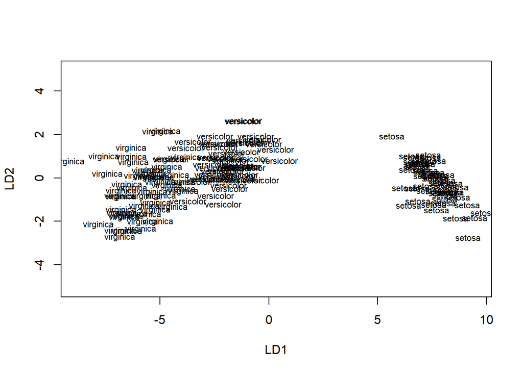

```r
# Gráfico de LDA
plot(lda_iris)
```